# Practical Machine Learning Course Project

## Summary

The goal of this project is predict whether weight-lift exercises were performed as recommended. It uses the experimental design and data from [Qualitative Activity Recognition of Weight Lifting Exercises](http://groupware.les.inf.puc-rio.br/har). (Velloso, E.; Bulling, A.; Gellersen, H.; Ugulino, W.; Fuks, H. Qualitative Activity Recognition of Weight Lifting Exercises. Proceedings of 4th International Conference in Cooperation with SIGCHI (Augmented Human ’13) . Stuttgart, Germany: ACM SIGCHI, 2013).

## Data wrangling and first analysis

The data was ingested and splitted in two sets, the training one with 70% and the testing with 30%.

```r
# Data Ingestion
theURL <- "https://d396qusza40orc.cloudfront.net/predmachlearn/pml-training.csv"

if(file_test("-f", "pml-training.csv") == FALSE)
  {
  download.file(theURL,"pml-training.csv",mode = "wb")
}

traindata <- read.csv("pml-training.csv", na.strings = c("","NA","NULL"))


# Spliting
set.seed(1969)
indice <- createDataPartition(y= traindata$classe, p = .70, list=FALSE)
training <- traindata[indice,]
testing <- traindata[-indice,]
```

It seems that there are two classes of features, regarding their origin. The majority relates to the measures of the exercises and the others are metadata from the experiments (e.g. user names e timestamp).

### Metadata features

We found a perfect correlation between *raw_timestamp_part_1* and *cvtd_timestamp*, meaning that they express the same thing, so we can drop one of them

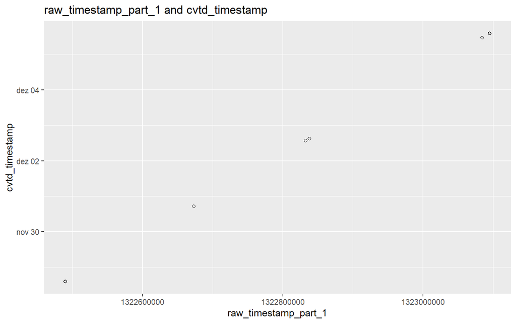

```r
g1 <- ggplot(data=training, aes(x=as.numeric(raw_timestamp_part_1), y = dmy_hm(cvtd_timestamp))) +
  geom_point(shape =1, position=position_jitter(width=2,height=2)) +
  labs(x = "raw_timestamp_part_1", y = "cvtd_timestamp") +
  ggtitle ("raw_timestamp_part_1 and cvtd_timestamp")
g1
```

We found an almost deterministic relationship between *num_window* and *classe*, suggesting that the experimental design carried out series of repeated measures by *classe* and *user_name*, as showed next plot.

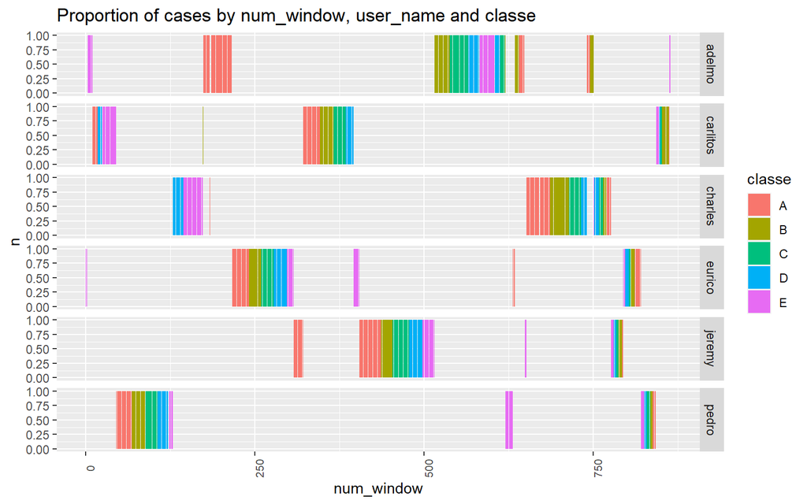

```r
temp <- training %>%
  count(classe, num_window,user_name)

g2 <- ggplot(temp, aes(fill=classe, y=n, x=num_window)) +
    geom_bar(position="fill", stat="identity") + facet_grid (user_name ~ .) +
  theme(axis.text.x= element_text(size = 8, angle = 90)) + ggtitle ("Proportion of cases by num_window, user_name and classe")
rm(temp)
g2
```

```r
if(file_test("-f", "ml_rf.RDS") == FALSE)
  {
  ml_rf <- train(classe ~ num_window + user_name, method = "rf", data = training)
  saveRDS(ml_rf, "ml_rf.RDS")
}
ml_rf <- readRDS("ml_rf.RDS")

# in sample performance
confusionMatrix(predict(ml_rf, newdata = training[,-160]), reference = as.factor(training[,160]))
```

```
## Confusion Matrix and Statistics
##
##           Reference
## Prediction    A    B    C    D    E
##          A 3906    0    0    0    0
##          B    0 2658    0    0    0
##          C    0    0 2396    0    0
##          D    0    0    0 2252    0
##          E    0    0    0    0 2525
##
## Overall Statistics
##
##                Accuracy : 1
##                  95% CI : (0.9997, 1)
##     No Information Rate : 0.2843
##     P-Value [Acc > NIR] : < 2.2e-16
##
##                   Kappa : 1
##
##  Mcnemar's Test P-Value : NA
##
## Statistics by Class:
##
##                      Class: A Class: B Class: C Class: D Class: E
## Sensitivity            1.0000   1.0000   1.0000   1.0000   1.0000
## Specificity            1.0000   1.0000   1.0000   1.0000   1.0000
## Pos Pred Value         1.0000   1.0000   1.0000   1.0000   1.0000
## Neg Pred Value         1.0000   1.0000   1.0000   1.0000   1.0000
## Prevalence             0.2843   0.1935   0.1744   0.1639   0.1838
## Detection Rate         0.2843   0.1935   0.1744   0.1639   0.1838
## Detection Prevalence   0.2843   0.1935   0.1744   0.1639   0.1838
## Balanced Accuracy      1.0000   1.0000   1.0000   1.0000   1.0000
```

```r
#outsample performance
confusionMatrix(predict(ml_rf, newdata = testing[,-160]), reference = as.factor(testing[,160]))
```

```
## Confusion Matrix and Statistics
##
##           Reference
## Prediction    A    B    C    D    E
##          A 1674    0    0    0    3
##          B    0 1139    0    0    0
##          C    0    0 1026    0    0
##          D    0    0    0  964    1
##          E    0    0    0    0 1078
##
## Overall Statistics
##
##                Accuracy : 0.9993
##                  95% CI : (0.9983, 0.9998)
##     No Information Rate : 0.2845
##     P-Value [Acc > NIR] : < 2.2e-16
##
##                   Kappa : 0.9991
##
##  Mcnemar's Test P-Value : NA
##
## Statistics by Class:
##
##                      Class: A Class: B Class: C Class: D Class: E
## Sensitivity            1.0000   1.0000   1.0000   1.0000   0.9963
## Specificity            0.9993   1.0000   1.0000   0.9998   1.0000
## Pos Pred Value         0.9982   1.0000   1.0000   0.9990   1.0000
## Neg Pred Value         1.0000   1.0000   1.0000   1.0000   0.9992
## Prevalence             0.2845   0.1935   0.1743   0.1638   0.1839
## Detection Rate         0.2845   0.1935   0.1743   0.1638   0.1832
## Detection Prevalence   0.2850   0.1935   0.1743   0.1640   0.1832
## Balanced Accuracy      0.9996   1.0000   1.0000   0.9999   0.9982
```

### Measurement features

Although the instructions for this project grants the use of any feature available in the training dataset, we decide to stick with the principles of the original paper and kept only the measurement variables, as the original main goal was to use the measures of movement as predictors, not the metadata. So, we decided to drop the metadata features and go on with the measurement ones.

```r
# Data assessment
dataquality <- skim_without_charts(training[,-c(1:7)])
head(dataquality,10)
```

Data summary

| Name | training[, -c(1:7)] |
| --- | --- |
| Number of rows | 13737 |
| Number of columns | 153 |
| _______________________ |  |
| Column type frequency: |  |
| character | 10 |
| ________________________ |  |
| Group variables | None |

**Variable type: character**

| skim_variable | n_missing | complete_rate | min | max | empty | n_unique | whitespace |
| --- | --- | --- | --- | --- | --- | --- | --- |
| kurtosis_roll_belt | 13445 | 0.02 | 7 | 9 | 0 | 285 | 0 |
| kurtosis_picth_belt | 13445 | 0.02 | 7 | 9 | 0 | 237 | 0 |
| kurtosis_yaw_belt | 13445 | 0.02 | 7 | 7 | 0 | 1 | 0 |
| skewness_roll_belt | 13445 | 0.02 | 7 | 9 | 0 | 282 | 0 |
| skewness_roll_belt.1 | 13445 | 0.02 | 7 | 9 | 0 | 252 | 0 |
| skewness_yaw_belt | 13445 | 0.02 | 7 | 7 | 0 | 1 | 0 |
| max_yaw_belt | 13445 | 0.02 | 3 | 7 | 0 | 59 | 0 |
| min_yaw_belt | 13445 | 0.02 | 3 | 7 | 0 | 59 | 0 |
| amplitude_yaw_belt | 13445 | 0.02 | 4 | 7 | 0 | 3 | 0 |
| kurtosis_roll_arm | 13445 | 0.02 | 7 | 8 | 0 | 239 | 0 |

There are 100 features with complete rate near to 0.02. This missingness is probably Missing at Random (MAR), since there is a pattern, being the amount of missing values the same across the features and cases. We choose to drop those features because it’s hard to make a good inference on their values based on so scarce data.

```r
temp <- subset(dataquality, complete_rate > 0.022)
training <- training[, temp$skim_variable]
rm(temp)

# final dataset to modeling
colnames(training)
```

```
##  [1] "classe"               "roll_belt"            "pitch_belt"
##  [4] "yaw_belt"             "total_accel_belt"     "gyros_belt_x"
##  [7] "gyros_belt_y"         "gyros_belt_z"         "accel_belt_x"
## [10] "accel_belt_y"         "accel_belt_z"         "magnet_belt_x"
## [13] "magnet_belt_y"        "magnet_belt_z"        "roll_arm"
## [16] "pitch_arm"            "yaw_arm"              "total_accel_arm"
## [19] "gyros_arm_x"          "gyros_arm_y"          "gyros_arm_z"
## [22] "accel_arm_x"          "accel_arm_y"          "accel_arm_z"
## [25] "magnet_arm_x"         "magnet_arm_y"         "magnet_arm_z"
## [28] "roll_dumbbell"        "pitch_dumbbell"       "yaw_dumbbell"
## [31] "total_accel_dumbbell" "gyros_dumbbell_x"     "gyros_dumbbell_y"
## [34] "gyros_dumbbell_z"     "accel_dumbbell_x"     "accel_dumbbell_y"
## [37] "accel_dumbbell_z"     "magnet_dumbbell_x"    "magnet_dumbbell_y"
## [40] "magnet_dumbbell_z"    "roll_forearm"         "pitch_forearm"
## [43] "yaw_forearm"          "total_accel_forearm"  "gyros_forearm_x"
## [46] "gyros_forearm_y"      "gyros_forearm_z"      "accel_forearm_x"
## [49] "accel_forearm_y"      "accel_forearm_z"      "magnet_forearm_x"
## [52] "magnet_forearm_y"     "magnet_forearm_z"
```

## Pre processing

Some variables are high correlated:

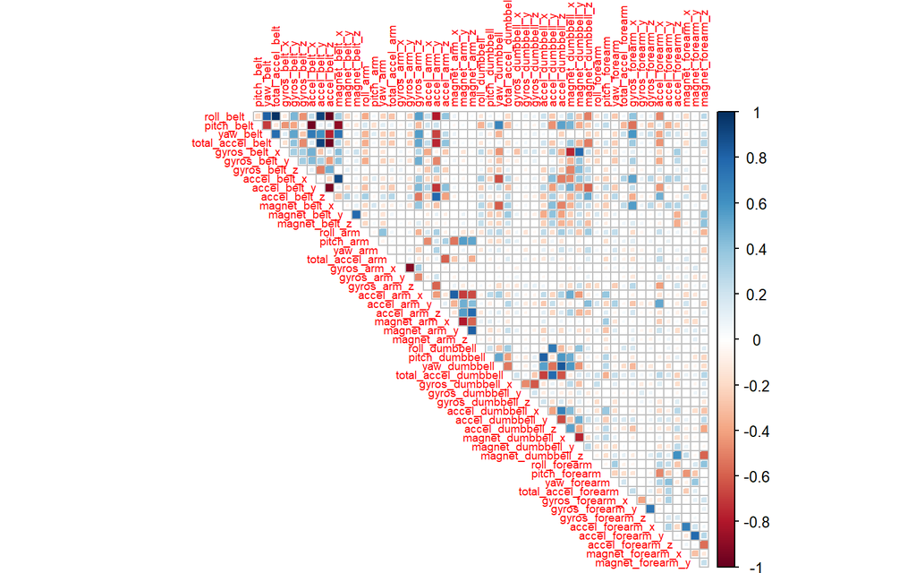

```r
corrplot(cor(training[,-1]),
         method = "square",
         type = "upper", diag = FALSE,
         tl.cex = 0.6)
```

We have tried Principal Component Analysis (PCA) to reduce dimensionality. We kept 90% of the original variance with 20 components, but neither accuracy and interpretability were better than the model without PCA. So, preprocessing was just centering and scaling the variables.

```r
preProc <- preProcess(training[, -1], method = c("center", "scale"))
preProc
```

```
## Created from 13737 samples and 52 variables
##
## Pre-processing:
##   - centered (52)
##   - ignored (0)
##   - scaled (52)
```

```r
training <- predict(preProc, training)
```

## Modeling

A XGBoost model was trained on the prepared data set using the Caret package. We used the method “xgbtree” that needs seven parameters:

- nrounds (# Boosting Iterations)
- max_depth (Max Tree Depth)
- eta (Shrinkage)
- gamma (Minimum Loss Reduction)
- colsample_bytree (Subsample Ratio of Columns)
- min_child_weight (Minimum Sum of Instance Weight)
- subsample (Subsample Percentage)

```r
fitControl <- trainControl (method = "repeatedcv",
                            number = 10,
                            repeats = 10)

if(file_test("-f", "ml_xgboost2.RDS") == FALSE)
  {
  ml_xgboost2 <- train(classe ~ .,
                    method = "xgbTree",
                    trControl = fitControl,
                    data = training)
  saveRDS(ml_xgboost2, "ml_xgboost2.RDS")
}
ml_xgboost2 <- readRDS("ml_xgboost2.RDS")
```

```r
ml_xgboost2$finalModel
```

```
## ##### xgb.Booster
## Handle is invalid! Suggest using xgb.Booster.complete
## raw: 473.4 Kb
## call:
##   xgboost::xgb.train(params = list(eta = param$eta, max_depth = param$max_depth,
##     gamma = param$gamma, colsample_bytree = param$colsample_bytree,
##     min_child_weight = param$min_child_weight, subsample = param$subsample),
##     data = x, nrounds = param$nrounds, num_class = length(lev),
##     objective = "multi:softprob")
## params (as set within xgb.train):
##   eta = "0.4", max_depth = "3", gamma = "0", colsample_bytree = "0.8", min_child_weight = "1", subsample = "0.75", num_class = "5", objective = "multi:softprob", validate_parameters = "TRUE"
## callbacks:
##   cb.print.evaluation(period = print_every_n)
## # of features: 52
## niter: 150
## nfeatures : 52
## xNames : roll_belt pitch_belt yaw_belt total_accel_belt gyros_belt_x gyros_belt_y gyros_belt_z accel_belt_x accel_belt_y accel_belt_z magnet_belt_x magnet_belt_y magnet_belt_z roll_arm pitch_arm yaw_arm total_accel_arm gyros_arm_x gyros_arm_y gyros_arm_z accel_arm_x accel_arm_y accel_arm_z magnet…
## problemType : Classification
## tuneValue :
##      nrounds max_depth eta gamma colsample_bytree min_child_weight subsample
## 105     150         3 0.4     0              0.8                1      0.75
## obsLevels : A B C D E
## param :
##  list()
```

The final parameters were:

- nrounds = 150
- max_depth = 3
- eta = 0.4
- gamma = 0
- colsample_bytree = 0.8
- min_child_weight = 1
- subsample = 0.75

### Model’s performance

The in sample performance was

```r
confusionMatrix(predict(ml_xgboost2, newdata = training[,-1]), reference = as.factor(training[,1]))
```

```
## Confusion Matrix and Statistics
##
##           Reference
## Prediction    A    B    C    D    E
##          A 3906    0    0    0    0
##          B    0 2658    0    0    0
##          C    0    0 2396    0    0
##          D    0    0    0 2252    0
##          E    0    0    0    0 2525
##
## Overall Statistics
##
##                Accuracy : 1
##                  95% CI : (0.9997, 1)
##     No Information Rate : 0.2843
##     P-Value [Acc > NIR] : < 2.2e-16
##
##                   Kappa : 1
##
##  Mcnemar's Test P-Value : NA
##
## Statistics by Class:
##
##                      Class: A Class: B Class: C Class: D Class: E
## Sensitivity            1.0000   1.0000   1.0000   1.0000   1.0000
## Specificity            1.0000   1.0000   1.0000   1.0000   1.0000
## Pos Pred Value         1.0000   1.0000   1.0000   1.0000   1.0000
## Neg Pred Value         1.0000   1.0000   1.0000   1.0000   1.0000
## Prevalence             0.2843   0.1935   0.1744   0.1639   0.1838
## Detection Rate         0.2843   0.1935   0.1744   0.1639   0.1838
## Detection Prevalence   0.2843   0.1935   0.1744   0.1639   0.1838
## Balanced Accuracy      1.0000   1.0000   1.0000   1.0000   1.0000
```

The out of sample performance was

```r
temp <- subset(dataquality, complete_rate > 0.022)
testing <- testing[, temp$skim_variable]
rm(temp)

testing <- predict(preProc, testing) # preprocessing (PCA) testdata using preprocess from training data

cm <- confusionMatrix(predict(ml_xgboost2, newdata = testing[,-1]), reference = as.factor(testing[,1]))
cm
```

```
## Confusion Matrix and Statistics
##
##           Reference
## Prediction    A    B    C    D    E
##          A 1674    0    0    0    0
##          B    0 1137    4    0    0
##          C    0    2 1017    4    0
##          D    0    0    5  960    1
##          E    0    0    0    0 1081
##
## Overall Statistics
##
##                Accuracy : 0.9973
##                  95% CI : (0.9956, 0.9984)
##     No Information Rate : 0.2845
##     P-Value [Acc > NIR] : < 2.2e-16
##
##                   Kappa : 0.9966
##
##  Mcnemar's Test P-Value : NA
##
## Statistics by Class:
##
##                      Class: A Class: B Class: C Class: D Class: E
## Sensitivity            1.0000   0.9982   0.9912   0.9959   0.9991
## Specificity            1.0000   0.9992   0.9988   0.9988   1.0000
## Pos Pred Value         1.0000   0.9965   0.9941   0.9938   1.0000
## Neg Pred Value         1.0000   0.9996   0.9981   0.9992   0.9998
## Prevalence             0.2845   0.1935   0.1743   0.1638   0.1839
## Detection Rate         0.2845   0.1932   0.1728   0.1631   0.1837
## Detection Prevalence   0.2845   0.1939   0.1738   0.1641   0.1837
## Balanced Accuracy      1.0000   0.9987   0.9950   0.9973   0.9995
```

```r
cm <- as.data.frame((cm$byClass))
Avg_precision <- mean(cm$`Pos Pred Value`)
```

The importance of each variable can be assessed in the next table

```r
varImp(ml_xgboost2)
```

```
## xgbTree variable importance
##
##   only 20 most important variables shown (out of 52)
##
##                   Overall
## roll_belt          100.00
## yaw_belt            80.07
## magnet_dumbbell_z   55.32
## pitch_forearm       53.54
## roll_forearm        46.65
## magnet_dumbbell_y   44.52
## pitch_belt          40.03
## magnet_belt_z       38.27
## accel_belt_z        37.48
## gyros_belt_z        25.97
## accel_dumbbell_z    20.56
## accel_dumbbell_y    20.19
## accel_forearm_z     18.19
## magnet_belt_y       18.18
## accel_arm_x         17.64
## accel_forearm_x     16.02
## magnet_arm_z        14.87
## roll_dumbbell       14.73
## accel_arm_z         12.69
## gyros_dumbbell_y    12.54
```

The acuracy and averaged precision reached 99,7%. This values can be compared with the original paper ones, 98,2% in both measures. This improvement in performance may be credited to the algorithm itself and the carefully tunning of parameters, what was achieved with a reasonably computational cost (circa 5 hours to trainining the model).

## Prediction and final assessment

```r
# Load test data

theURL <- "https://d396qusza40orc.cloudfront.net/predmachlearn/pml-testing.csv"

if(file_test("-f", "pml-testing.csv") == FALSE)
{
  download.file(theURL,"pml-testing.csv",mode = "wb")
}

testdata <- read.csv("pml-testing.csv", na.strings = c("","NA","NULL"))

names.use <- names(testdata)[(names(testdata) %in% dataquality$skim_variable)]

testdata <- testdata[ , names.use]

temp <- subset(dataquality, complete_rate > 0.022)
temp <- temp[-1,] # drop the target
testing <- testdata[, temp$skim_variable]
rm(temp)

# Preprocessing

testing <- predict(preProc, testing)

predicted <- predict(ml_xgboost2, newdata = testing)
predicted
```

```
##  [1] B A B A A E D B A A B C B A E E A B B B
## Levels: A B C D E
```